# Duncan Prestige Regression Example

Jeffrey B. Arnold

04/21/2015

This example will use Duncan’s Occpational Prestige Data, which has data on prestige and other characteristics of 45 U.S. occupations in 1950. See the help page for more info. This data is contained in the **car** package.

```r
library("car")
data("Duncan")
```

```r
?Duncan
```

We’ll also use a few other packages, which we should load now.

```r
library("ggplot2")
library("dplyr")
library("broom")
```

The `Duncan` data frame contains the names of the profession as row names. This is something that is generally discouraged in modern R, so we will make a new column named `occupation`.

This uses the `$` to assign a value to a column in R. We’ve been using **dplyr** so much that we haven’t had to do this, but it can be easier at times. This could have also been done using the dplyr function `add_rownames`.

```r
Duncan <- add_rownames(Duncan, var = "occupation")
```

Without **dplyr** we would have used

```r
# Duncan$occupation <- rownames(Duncan)
```

## Scatterplots

Before starting let’s create a couple of scatterplots of the data. First, prestige vs. income, labeling the points, and coloring them by type.

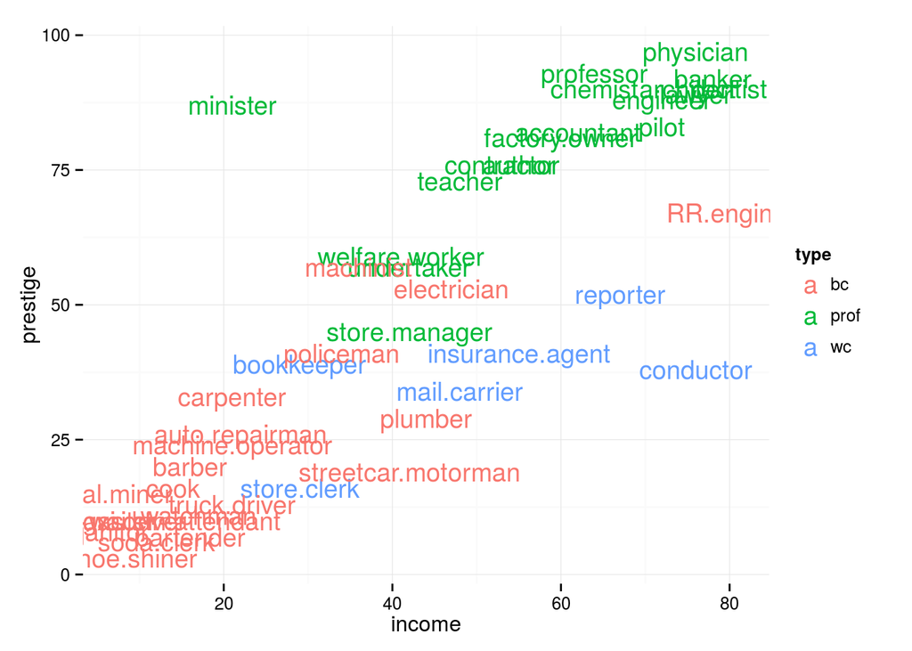

```r
ggplot(Duncan, aes(x = income, y = prestige, colour = type,
                   label = occupation)) +
  geom_text() +
  theme_minimal()
```

Now, prestige vs. income, coloring the points by education level:

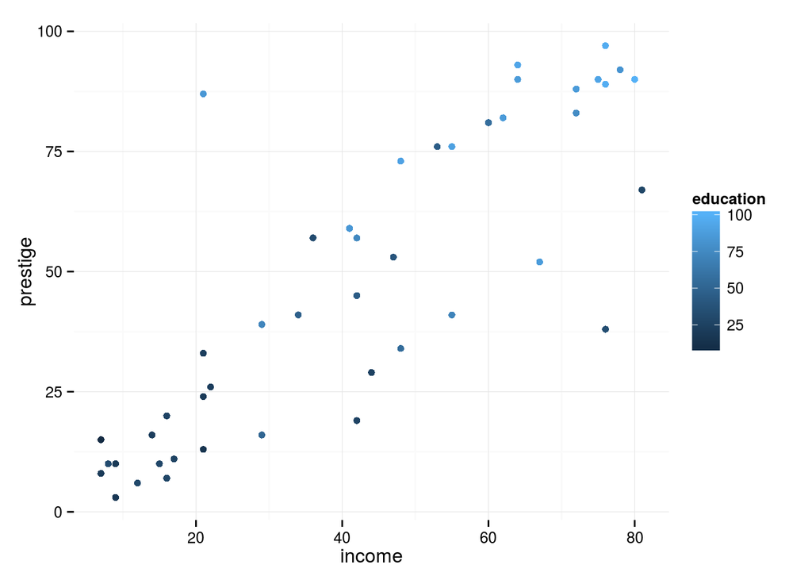

```r
ggplot(Duncan, aes(x = income, y = prestige, colour = education)) +
  geom_point() +
  theme_minimal()
```

Run a regression of prestige on income and education

```r
mod1 <- lm(prestige ~ income + education, data = Duncan)
mod1_summary <- summary(mod1)
mod1_summary
```

```
##
## Call:
## lm(formula = prestige ~ income + education, data = Duncan)
##
## Residuals:
##     Min      1Q  Median      3Q     Max
## -29.538  -6.417   0.655   6.605  34.641
##
## Coefficients:
##             Estimate Std. Error t value Pr(>|t|)
## (Intercept) -6.06466    4.27194  -1.420    0.163
## income       0.59873    0.11967   5.003 1.05e-05 ***
## education    0.54583    0.09825   5.555 1.73e-06 ***
## ---
## Signif. codes:  0 '***' 0.001 '**' 0.01 '*' 0.05 '.' 0.1 ' ' 1
##
## Residual standard error: 13.37 on 42 degrees of freedom
## Multiple R-squared:  0.8282, Adjusted R-squared:   0.82
## F-statistic: 101.2 on 2 and 42 DF,  p-value: < 2.2e-16
```

This extracts the coefficient estimates $\hat{\beta}$,

```r
beta <- coef(mod1)
```

This extracts the variance covariance matrix of the coefficient estimatates $V(\hat{\beta})$.

```r
beta_vc <- vcov(mod1)
```

Standard errors of the coefficients are $se(\hat{\beta}) = \sqrt{diag(V(\hat{\beta}))}$,

```r
beta_se <- sqrt(diag(beta_vc))
```

The $t$-statistic of the hypothesis test $\beta = 0$ is $\frac{\hat{\beta}}{se(\hat{\beta})}$,

```r
tstat <- beta / beta_se
```

And the $p$-value of the two-sided hypothesis test $H_0: \beta = 0$, $H_a: \beta \neq 0$ is,

```r
pval <- 2 * (1 - pt(tstat, mod1$df.residual))
```

The degrees of freedom $n - k - 1$

```r
mod1$df.residual
```

```
## [1] 42
```

The coefficients, $\hat{\beta}$:

```r
coef(mod1)
```

```
## (Intercept)      income   education
##  -6.0646629   0.5987328   0.5458339
```

The coefficients can also be extracted directly from the element in the `lm` object

```r
mod1$coefficients
```

```
## (Intercept)      income   education
##  -6.0646629   0.5987328   0.5458339
```

The fitted values, $\hat{y}$ (of the data used for fitting the regression).

```r
head(fitted(mod1))
```

```
##        1        2        3        4        5        6
## 77.99849 78.52748 89.05702 75.99069 79.19595 52.35877
```

```r
head(mod1$fitted)
```

```
##        1        2        3        4        5        6
## 77.99849 78.52748 89.05702 75.99069 79.19595 52.35877
```

The residuals, $\hat{epsilon} = y - \hat{y}$:

```r
head(residuals(mod1))
```

```
##            1            2            3            4            5
##  4.001511779  4.472522658  0.942981643  0.009305892 10.804046136
##            6
## 34.641225280
```

```r
head(mod1$residuals)
```

```
##            1            2            3            4            5
##  4.001511779  4.472522658  0.942981643  0.009305892 10.804046136
##            6
## 34.641225280
```

You can check that the residuals are $y - \hat{y}$,

```r
head(Duncan$prestige - fitted(mod1))
```

```
##            1            2            3            4            5
##  4.001511779  4.472522658  0.942981643  0.009305892 10.804046136
##            6
## 34.641225280
```

To get the data used in the regression back from the regression,

```r
head(model.frame(mod1))
```

```
##   prestige income education
## 1       82     62        86
## 2       83     72        76
## 3       90     75        92
## 4       76     55        90
## 5       90     64        86
## 6       87     21        84
```

To get the $y$ values (model or design matrix) used in the regression,

```r
head(model.response(model.frame(mod1)))
```

```
##  1  2  3  4  5  6
## 82 83 90 76 90 87
```

Note that if you have missing values in the regression, R has sophisticated but subtle ways of handling them, especially in `predict`. See the help for `na.omit` and follow links about `lm`.

The `anova` function returns a table with the total, model, and residual sum of squares.

```r
anova(mod1)
```

```
## Analysis of Variance Table
##
## Response: prestige
##           Df  Sum Sq Mean Sq F value    Pr(>F)
## income     1 30664.8 30664.8 171.570 < 2.2e-16 ***
## education  1  5516.1  5516.1  30.863 1.727e-06 ***
## Residuals 42  7506.7   178.7
## ---
## Signif. codes:  0 '***' 0.001 '**' 0.01 '*' 0.05 '.' 0.1 ' ' 1
```

## Result post-processing with broom

[Broom](https://github.com/dgrtwo/broom) is a relatively new package that works well with the **dplyr** and `%>%` workflow by converting the results of common models into data frames that can be processed more easily than the default objects R returns.

**broom** has three main functions, all of which return data frames (not lists, numeric vectors, or other types of object). `glance` returns a data frame with a single row summary of the model:

```r
glance(mod1)
```

```
##   r.squared adj.r.squared    sigma statistic      p.value df    logLik
## 1 0.8281734     0.8199912 13.36903  101.2162 8.647636e-17  3 -178.9822
##        AIC      BIC deviance df.residual
## 1 365.9645 373.1911 7506.699          42
```

`tidy` returns a data frame with a row for each coefficient estimate:

```r
tidy(mod1)
```

```
##          term   estimate  std.error statistic      p.value
## 1 (Intercept) -6.0646629 4.27194117 -1.419650 1.630896e-01
## 2      income  0.5987328 0.11966735  5.003310 1.053184e-05
## 3   education  0.5458339 0.09825264  5.555412 1.727192e-06
```

`augment` returns the original data frame used in the model with additional columns for fitted values, the standard errors of those fitted values, residuals, etc.

```r
head(augment(mod1))
```

```
##   prestige income education  .fitted  .se.fit       .resid       .hat
## 1       82     62        86 77.99849 3.017029  4.001511779 0.05092832
## 2       83     72        76 78.52748 3.200759  4.472522658 0.05732001
## 3       90     75        92 89.05702 3.527929  0.942981643 0.06963699
## 4       76     55        90 75.99069 3.405677  0.009305892 0.06489441
## 5       90     64        86 79.19595 3.028764 10.804046136 0.05132528
## 6       87     21        84 52.35877 5.561551 34.641225280 0.17305816
##     .sigma      .cooksd   .std.resid
## 1 13.51587 1.688452e-03 0.3072378711
## 2 13.51194 2.406367e-03 0.3445645225
## 3 13.53022 1.334199e-04 0.0731269019
## 4 13.53108 1.198619e-08 0.0007198265
## 5 13.41973 1.241505e-02 0.8297130469
## 6 12.15304 5.663797e-01 2.8494163845
```

## Coefficient Plots

Also known as airplane plots or ropeladder plots:

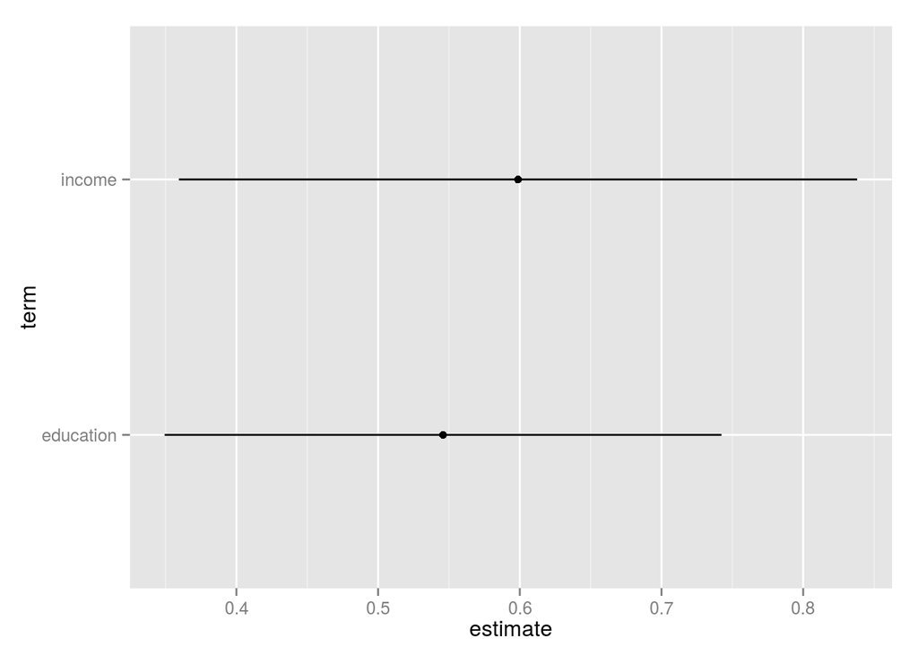

```r
ggplot(tidy(mod1) %>% filter(term != "(Intercept)"),
       aes(x = term, y = estimate,
           ymin = estimate - 2 * std.error,
           ymax = estimate + 2 * std.error)) +
  geom_pointrange() +
  coord_flip()
```

This could also be done with the `coefplot` function from the **coefplot** package:

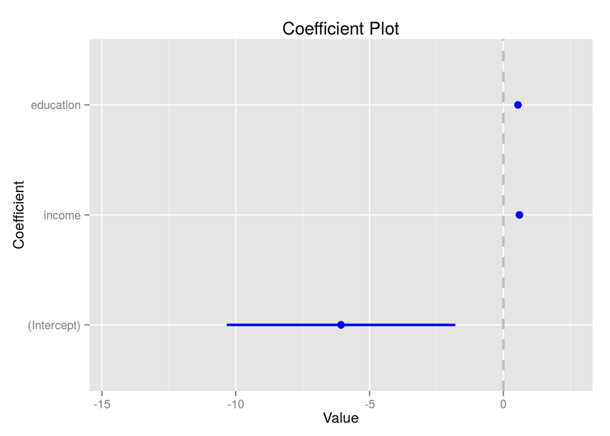

```r
library("coefplot")
coefplot(mod1)
```

or to drop the intercept

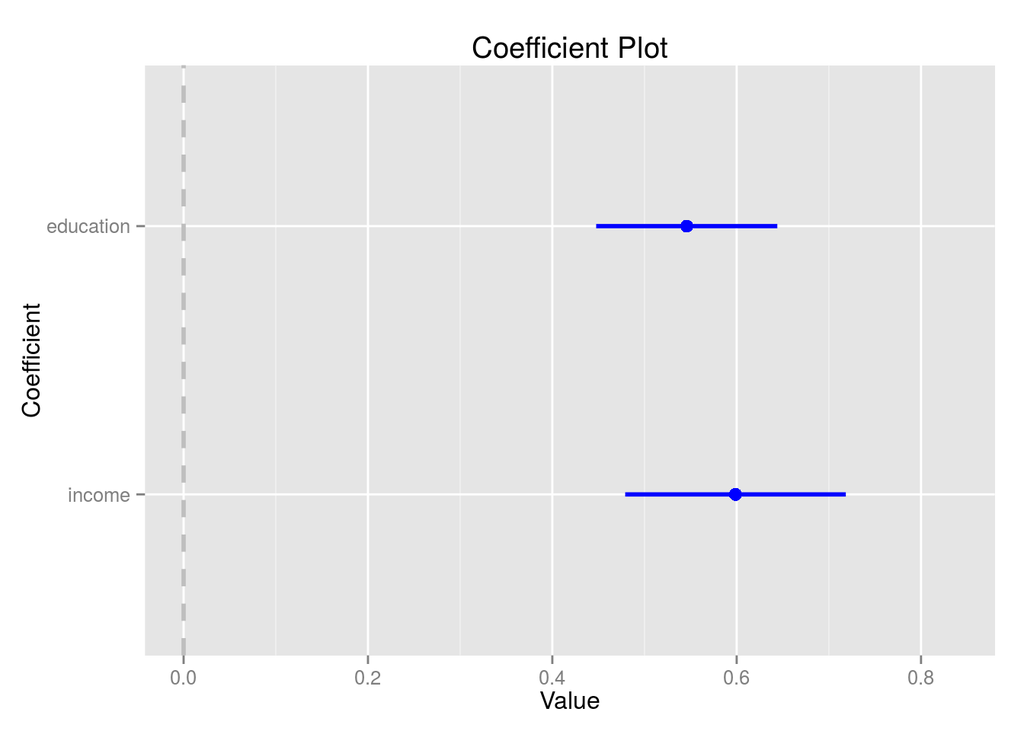

```r
coefplot(mod1, coefficients = c("income", "education"))
```

Since internally `coefplot` uses **ggplot2**, you could also edit the object it returns.

## Creating regression tables

Several packages (**stargazer**, **texreg**, **apsrtable**) are useful for creating publication type regression tables. **stargazer** and **texreg** are the most complete package. Both allow output to either LaTeX or HTML tables for many types of statistical models. We’ll use **stargazer** here:

```r
library("stargazer")
stargazer(mod1, type = "text")
```

```
##
## ===============================================
##                         Dependent variable:
##                     ---------------------------
##                              prestige
## -----------------------------------------------
## income                       0.599***
##                               (0.120)
##
## education                    0.546***
##                               (0.098)
##
## Constant                      -6.065
##                               (4.272)
##
## -----------------------------------------------
## Observations                    45
## R2                             0.828
## Adjusted R2                    0.820
## Residual Std. Error      13.369 (df = 42)
## F Statistic           101.216*** (df = 2; 42)
## ===============================================
## Note:               *p<0.1; **p<0.05; ***p<0.01
```

Now render that as html instead,

```r
stargazer(mod1, type = "html")
```

|  | *Dependent variable:* |
| --- | --- |
|  | prestige |
| income | 0.599*** |
|  | (0.120) |
| education | 0.546*** |
|  | (0.098) |
| Constant | -6.065 |
|  | (4.272) |
| Observations | 45 |
| R<sup>2</sup> | 0.828 |
| Adjusted R<sup>2</sup> | 0.820 |
| Residual Std. Error | 13.369 (df = 42) |
| F Statistic | 101.216*** (df = 2; 42) |
| *Note:* | p<0.1; p<0.05; p<0.01 |

Look at the source `.Rmd` file for this document; the chunk above used `results = "asis"` to print and render the HTML rather than R output.

This usefulness of this function is apparent when multiple regressions are plotted:

```r
mod3 <- lm(prestige ~ income, data = Duncan)
mod4 <- lm(prestige ~ income * type + education * type, data = Duncan)
stargazer(mod1, mod3, mod4, type = "html")
```

|  | *Dependent variable:* |  |  |
| --- | --- | --- | --- |
|  | prestige |  |  |
|  | (1) | (2) | (3) |
| income | 0.599*** | 1.080*** | 0.783*** |
|  | (0.120) | (0.107) | (0.131) |
| typeprof |  |  | 32.008** |
|  |  |  | (14.109) |
| typewc |  |  | -7.043 |
|  |  |  | (20.638) |
| education | 0.546*** |  | 0.320 |
|  | (0.098) |  | (0.280) |
| income:typeprof |  |  | -0.369* |
|  |  |  | (0.204) |
| income:typewc |  |  | -0.360 |
|  |  |  | (0.260) |
| typeprof:education |  |  | 0.019 |
|  |  |  | (0.318) |
| typewc:education |  |  | 0.107 |
|  |  |  | (0.362) |
| Constant | -6.065 | 2.457 | -3.951 |
|  | (4.272) | (5.190) | (6.794) |
| Observations | 45 | 45 | 45 |
| R<sup>2</sup> | 0.828 | 0.702 | 0.923 |
| Adjusted R<sup>2</sup> | 0.820 | 0.695 | 0.906 |
| Residual Std. Error | 13.369 (df = 42) | 17.403 (df = 43) | 9.647 (df = 36) |
| F Statistic | 101.216*** (df = 2; 42) | 101.252*** (df = 1; 43) | 54.174*** (df = 8; 36) |
| *Note:* | p<0.1; p<0.05; p<0.01 |  |  |

Addtionally, the packages **xtable** and **pander** are not a specific to the problem of creating regression tables, but since they are more genral purpose, they are good for creating LaTeX / HTML / Markdown tables for a variety of R objects.

## Predicted values

You could calculate predicted values manually. For example, the predicted `prestige` from `mod1` of an occupation with an income of 41.9 and an `education` of 52.5 is

```r
coef(mod1)["(Intercept)"] + coef(mod1)["income"] * 41.9 + coef(mod1)["education"] * 52.5
```

```
## (Intercept)
##    47.67852
```

or

```r
c(1, 41.9, 52.5) %*% coef(mod1)
```

```
##          [,1]
## [1,] 47.67852
```

```r
head(predict(mod1))
```

```
##        1        2        3        4        5        6
## 77.99849 78.52748 89.05702 75.99069 79.19595 52.35877
```

But, if the `newdata` argument is used, then `predict` can be used to find the predicted values for new data points. To calculate the predicted value of the example above:

```r
predict(mod1, newdata = data.frame(education = 52.5, income = 41.9))
```

```
##        1
## 47.67852
```

You can find the confidence intervals by specifying `interval = "confidence"`.

```r
yhat <- predict(mod1, interval = "confidence")
```

A note on help for `predict`: `predict` works with many different types of analyses and object. You need to go to `?predict.lm` to get help for predict as it relates to `lm`.

To plot, convert to a data_frame

```r
yhat_df <- as.data.frame(yhat) %>% add_rownames(var = "occupation")
```

Now it is easy to plot in **ggplot2**

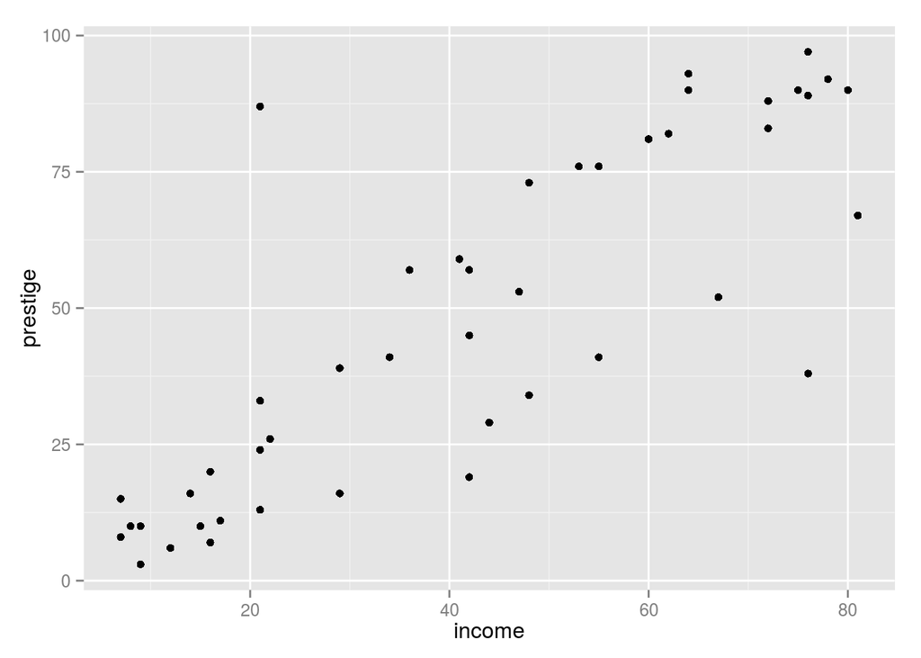

```r
ggplot() +
  geom_point(data = Duncan, aes(x = income, y = prestige))
```

Now do it with hypothetical values. All values of income observed in the data, but education at its mean.

```r
duncan_mean_education <-
  data.frame(education = mean(Duncan$education),
             income = seq(min(Duncan$income), max(Duncan$income),
                          length.out = 50))
mod1_predicted <- as.data.frame(predict(mod1, newdata = duncan_mean_education,
                                interval = "confidence", conf.level = 0.95))
# augment(mod1, newdata = duncan_mean_education) %>%
#   mutate(lower = .fitted + qt(0.025, mod1$df.residual) * .se.fit,
#          upper = .fitted + qt(0.975, mod1$df.residual) * .se.fit)
```

To plot this, we’ll need to combine it back with the original data.

```r
mod1_predicted <- cbind(duncan_mean_education, mod1_predicted)
```

Now, let’s plot the predicted values and the 95% confidence interval of predicted values as income changes. Additionally, we’ll plot the original values.

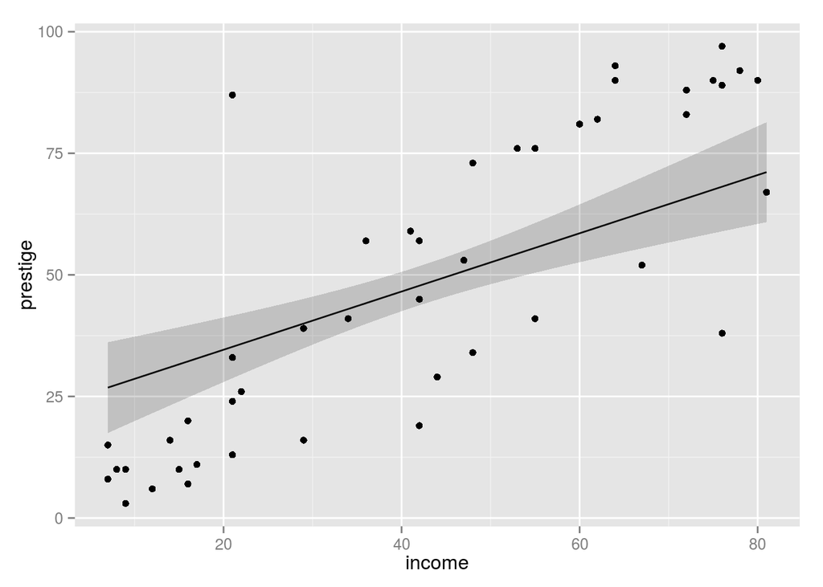

```r
ggplot() +
  geom_line(data = mod1_predicted, mapping = aes(x = income, y = fit)) +
  geom_ribbon(data = mod1_predicted, mapping = aes(x = income, ymin = lwr, ymax = upr),
              alpha = 0.2) +
  geom_point(data = Duncan, mapping = aes(x = income, y = prestige)) +
  ylab("prestige")
```

Note that we use different datasets in each `geom`, and do not use any values in `ggplot`. The `ggplot` function can provide default mappings in `aes` and a default dataset. But if you are using multiple datasets, it can be safter and less buggy to specify a `data` and `mapping` argument for each `geom` layer.

For more interesting predicted value plots, let’s run a regression with a categorical variable.

```r
mod2 <- lm(prestige ~ income + education + type, data = Duncan)
mod2
```

```
##
## Call:
## lm(formula = prestige ~ income + education + type, data = Duncan)
##
## Coefficients:
## (Intercept)       income    education     typeprof       typewc
##     -0.1850       0.5975       0.3453      16.6575     -14.6611
```

Now, let’s predict values for each type of occupation for all values of income, holding education at its mean value. First, we need to create the data that will be used for the predicted values. This can be made easier with the function `expand.grid`, which returns a data frame with all combinations of its arguments. For example,

```r
expand.grid(a = 1:3, b = c("a", "b"))
```

```
##   a b
## 1 1 a
## 2 2 a
## 3 3 a
## 4 1 b
## 5 2 b
## 6 3 b
```

With that information, let’s create data frame with the values needed for prediction

```r
newdata_types_inc <-
  expand.grid(type = unique(Duncan$type),
              income = seq(min(Duncan$income), max(Duncan$income),
                           length.out = 5),
              education = mean(Duncan$education))
# # Another method
# newdata_types_inc <-
#   Duncan %>% {
#     expand.grid(type = unique(.$type),
#                 income = seq(min(.$income), max(.$income),
#                             length.out = 5),
#                 education = mean(.$education))
#     }
```

Then, create predicted values and confidence intervals with either `predict` or `augment`.

```r
predicted_mod2 <-
  augment(mod2, newdata = newdata_types_inc) %>%
  mutate(lower = .fitted + qt(0.025, mod2$df.residual) * .se.fit,
         upper = .fitted + qt(0.975, mod2$df.residual) * .se.fit)
```

And then plot it,

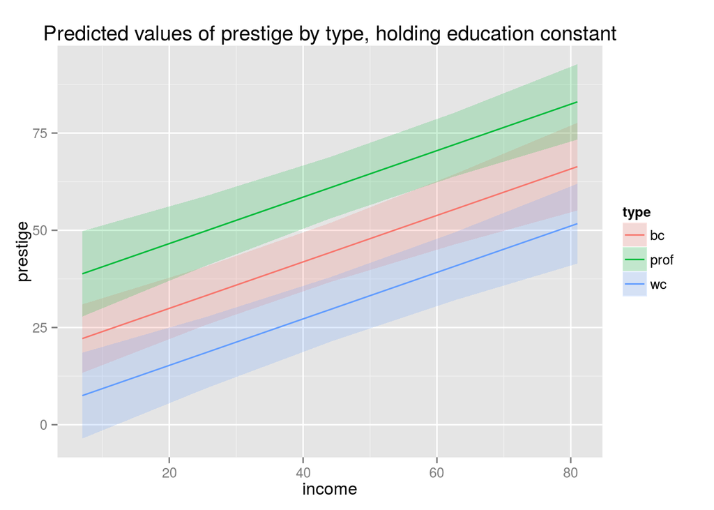

```r
ggplot(predicted_mod2, aes(x = income, y = .fitted,
                           ymin = lower, ymax = upper)) +
  geom_line(mapping = aes(colour = type)) +
  geom_ribbon(mapping = aes(fill = type), alpha = 0.2) +
  ylab("prestige") +
  ggtitle("Predicted values of prestige by type, holding education constant")
```